# STAT 349 Final Project Report

### Kenny Jin

```r
library(tseries)
library(TSA)
```

Note: log based 10 is always used in this project Some of the dataset is replaced because of the length. Current datasets (* means replaced):

*BLL F *LLY LOW MCO MSFT PFE ROK *TRV *TXT

```r
library(readxl)
read_excel_allsheets <- function(filename, tibble = FALSE) {
    # I prefer straight data.frames
    # but if you like tidyverse tibbles (the default with read_excel)
    # then just pass tibble = TRUE
    sheets <- readxl::excel_sheets(filename)
    x <- lapply(sheets, function(X) readxl::read_excel(filename, sheet = X))
    if(!tibble) x <- lapply(x, as.data.frame)
    names(x) <- sheets
    x
}
mysheets <- read_excel_allsheets("KennyJin.xlsx")
```

```r
select_best_model <- function(data, max_p=2, max_q=2) {
  min_ssr <- Inf
  best_param <- c(-1, -1)
  best_model <- NULL
  # Find the model with the smallest sum square of residuals
  for (p in 1:max_p) {
    for (q in 1:max_q) {
      capture.output(model <- garch(x=data,order=c(p,q)))
      ssr <- sum(na.omit(model$residuals)^2)
      if (ssr < min_ssr) {
        min_ssr <- ssr
        best_param <- c(p, q)
        best_model <- model
      }
    }
  }
  print(min_ssr)
  print(best_param)
  return(best_param)
}
```

# 1 Steps 1-3

## 1.1 Dataset 1: Stock BLL

```r
BLL = mysheets$BLL
BLL.return = na.omit(BLL$`Log Return`)
```

### 1.1.1

```r
# prints ssr and best parameters
best_params <- select_best_model(BLL.return)
```

```
## [1] 3740.503
## [1] 1 2
```

```r
o = capture.output(mpq <- garch(x=BLL.return,order=best_params))
```

```r
summary(mpq)
```

```
##
## Call:
## garch(x = BLL.return, order = best_params)
##
## Model:
## GARCH(1,2)
##
## Residuals:
##      Min       1Q   Median       3Q      Max
## -8.12455 -0.49526  0.03929  0.57964 10.91165
##
## Coefficient(s):
##     Estimate  Std. Error  t value Pr(>|t|)
## a0 4.892e-06   2.768e-07   17.675  < 2e-16 ***
## a1 7.677e-02   1.227e-02    6.258 3.90e-10 ***
## a2 1.441e-01   2.072e-02    6.954 3.54e-12 ***
## b1 6.926e-01   1.611e-02   42.980  < 2e-16 ***
## ---
## Signif. codes:  0 '***' 0.001 '**' 0.01 '*' 0.05 '.' 0.1 ' ' 1
##
## Diagnostic Tests:
##  Jarque Bera Test
##
## data:  Residuals
## X-squared = 7117.9, df = 2, p-value < 2.2e-16
##
##
##  Box-Ljung test
##
## data:  Squared.Residuals
## X-squared = 0.070794, df = 1, p-value = 0.7902
```

The best fitted model is GARCH(1,2) with the following estimated parameter values and standard errors.

Report the sum of the squared error of the final model.

```r
sum(na.omit(mpq$residuals)^2)
```

```
## [1] 3740.503
```

State the reason why this model is the final model.

GARCH(1,2) gives the smallest sum of squared residuals for this dataset.

### 1.1.2 Some diagnostic results

```r
shapiro.test(na.omit(residuals(mpq)))
```

```
##
##  Shapiro-Wilk normality test
##
## data:  na.omit(residuals(mpq))
## W = 0.95955, p-value < 2.2e-16
```

```r
jarque.bera.test(na.omit(residuals(mpq)))
```

```
##
##  Jarque Bera Test
##
## data:  na.omit(residuals(mpq))
## X-squared = 7117.9, df = 2, p-value < 2.2e-16
```

```r
cat('skewness: ', skewness(na.omit(residuals(mpq))), '\n')
```

```
## skewness:  0.1792892
```

```r
cat('kurtosis: ', kurtosis(na.omit(residuals(mpq))))
```

```
## kurtosis:  6.671514
```

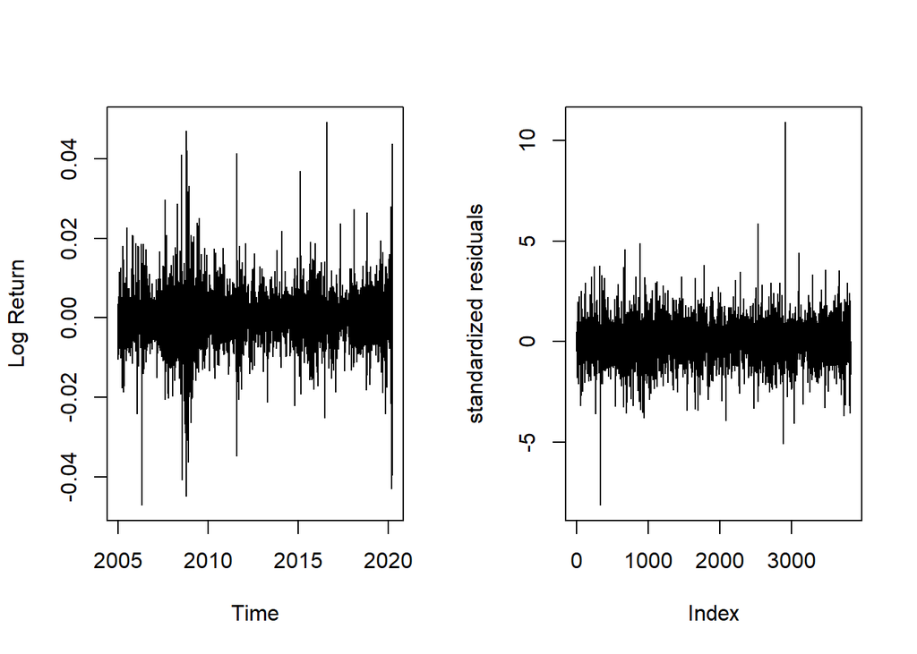

```r
par(mfrow=c(1,2))
plot(BLL$Date[-1], BLL.return, type='l', xlab='Time', ylab='Log Return')
# plot fitted residuals of the best GARCH model
plot(residuals(mpq),type='h',ylab='standardized residuals')
```

Figure: The left panel is the log return original series from 01/04/2005 to 03/20/2020. The right panel is the fitted residuals (standardized returns or pseudo- returns.)

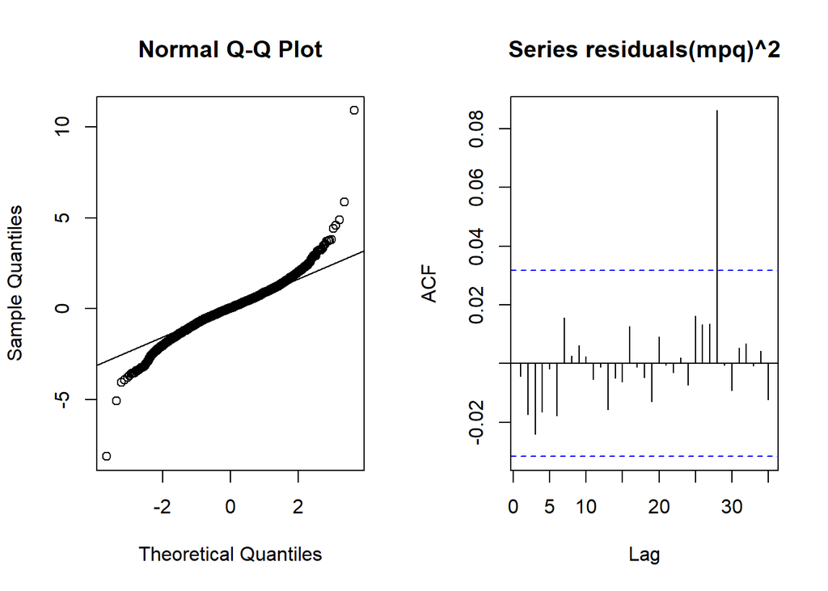

```r
par(mfrow=c(1,2))
qqnorm(residuals(mpq)); qqline(residuals(mpq))
acf(residuals(mpq)^2,na.action=na.omit)
```

Figure: The left panel is the residual QQ plot. The right panel is the squared residual ACF plot.

```r
BLL.residual=na.omit(residuals(mpq))
```

## 1.2-1.10 Same as 1.1

## 1.2 Dataset 1: Stock F

```r
F = mysheets$F
F.return = na.omit(F$`Log Return`)
```

### 1.2.1

```r
# prints ssr and best parameters
best_params <- select_best_model(F.return)
```

```
## [1] 3669.49
## [1] 1 2
```

```r
o = capture.output(mpq <- garch(x=F.return,order=best_params))
```

```r
summary(mpq)
```

```
##
## Call:
## garch(x = F.return, order = best_params)
##
## Model:
## GARCH(1,2)
##
## Residuals:
##     Min      1Q  Median      3Q     Max
## -7.0528 -0.5422  0.0000  0.5238  6.9223
##
## Coefficient(s):
##     Estimate  Std. Error  t value Pr(>|t|)
## a0 4.217e-06   3.797e-07    11.11   <2e-16 ***
## a1 2.171e-01   1.711e-02    12.69   <2e-16 ***
## a2 8.688e-08   2.070e-02     0.00        1
## b1 7.777e-01   1.247e-02    62.37   <2e-16 ***
## ---
## Signif. codes:  0 '***' 0.001 '**' 0.01 '*' 0.05 '.' 0.1 ' ' 1
##
## Diagnostic Tests:
##  Jarque Bera Test
##
## data:  Residuals
## X-squared = 3814.9, df = 2, p-value < 2.2e-16
##
##
##  Box-Ljung test
##
## data:  Squared.Residuals
## X-squared = 0.30565, df = 1, p-value = 0.5804
```

The best fitted model is GARCH(1,2) with the following estimated parameter values and standard errors.

Report the sum of the squared error of the final model.

```r
sum(na.omit(mpq$residuals)^2)
```

```
## [1] 3669.49
```

State the reason why this model is the final model.

GARCH(1,2) gives the smallest sum of squared residuals for this dataset.

### 1.2.2 Some diagnostic results

```r
shapiro.test(na.omit(residuals(mpq)))
```

```
##
##  Shapiro-Wilk normality test
##
## data:  na.omit(residuals(mpq))
## W = 0.95581, p-value < 2.2e-16
```

```r
jarque.bera.test(na.omit(residuals(mpq)))
```

```
##
##  Jarque Bera Test
##
## data:  na.omit(residuals(mpq))
## X-squared = 3814.9, df = 2, p-value < 2.2e-16
```

```r
cat('skewness: ', skewness(na.omit(residuals(mpq))), '\n')
```

```
## skewness:  -0.4561754
```

```r
cat('kurtosis: ', kurtosis(na.omit(residuals(mpq))))
```

```
## kurtosis:  4.805406
```

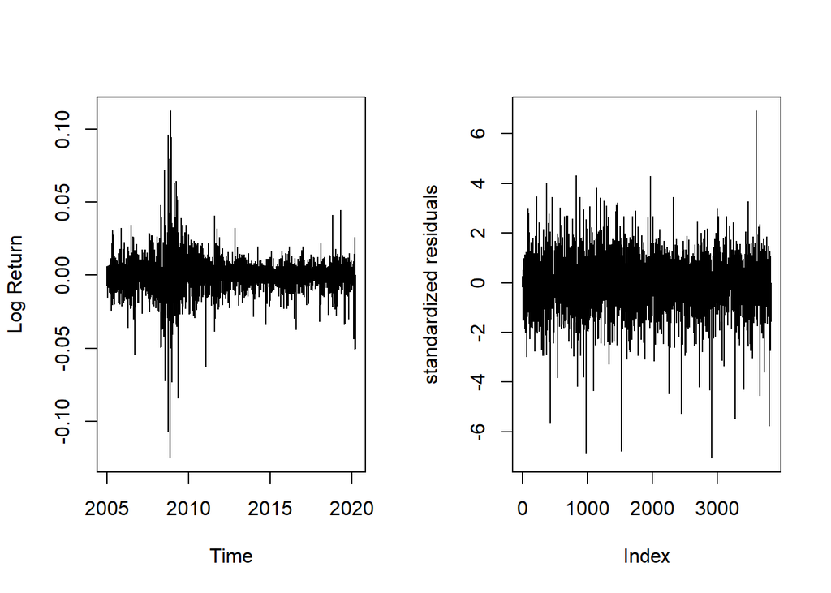

```r
par(mfrow=c(1,2))
plot(F$Date[-1], F.return, type='l', xlab='Time', ylab='Log Return')
# plot fitted residuals of the best GARCH model
plot(residuals(mpq),type='h',ylab='standardized residuals')
```

Figure: The left panel is the log return original series from 01/04/2005 to 03/20/2020. The right panel is the fitted residuals (standardized returns or pseudo- returns.)

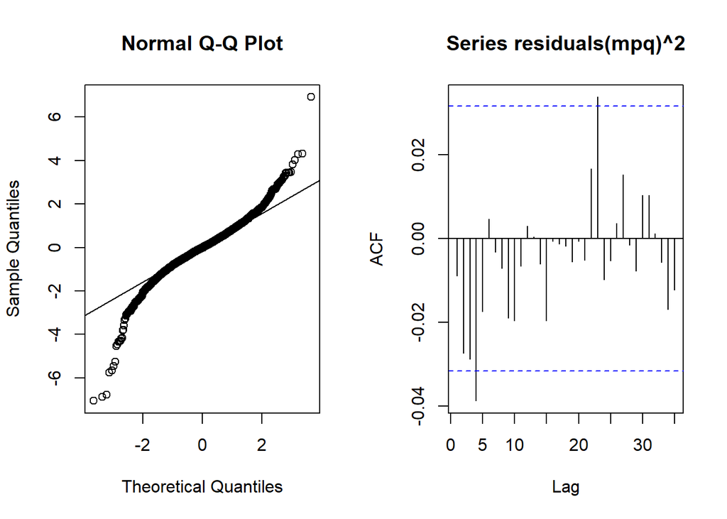

```r
par(mfrow=c(1,2))
qqnorm(residuals(mpq)); qqline(residuals(mpq))
acf(residuals(mpq)^2,na.action=na.omit)
```

Figure: The left panel is the residual QQ plot. The right panel is the squared residual ACF plot.

```r
F.residual=na.omit(residuals(mpq))
```

## 1.3 Dataset 1: Stock LLY

```r
LLY = mysheets$LLY
LLY.return = na.omit(LLY$`Log Return`)
```

The original log return series is plotted in Figure on the left panel. The fitted residuals (standardized returns or pseudo-returns) are plotted on the right panel.

### 1.3.1

```r
# prints ssr and best parameters
best_params <- select_best_model(LLY.return)
```

```
## [1] 3684.924
## [1] 1 2
```

```r
o = capture.output(mpq <- garch(x=LLY.return,order=best_params))
```

```r
summary(mpq)
```

```
##
## Call:
## garch(x = LLY.return, order = best_params)
##
## Model:
## GARCH(1,2)
##
## Residuals:
##      Min       1Q   Median       3Q      Max
## -8.41665 -0.51273  0.04902  0.57247  4.90148
##
## Coefficient(s):
##     Estimate  Std. Error  t value Pr(>|t|)
## a0 2.276e-06   1.848e-07    12.31   <2e-16 ***
## a1 1.912e-01   2.101e-02     9.10   <2e-16 ***
## a2 2.447e-10   2.276e-02     0.00        1
## b1 7.736e-01   1.170e-02    66.11   <2e-16 ***
## ---
## Signif. codes:  0 '***' 0.001 '**' 0.01 '*' 0.05 '.' 0.1 ' ' 1
##
## Diagnostic Tests:
##  Jarque Bera Test
##
## data:  Residuals
## X-squared = 2327.6, df = 2, p-value < 2.2e-16
##
##
##  Box-Ljung test
##
## data:  Squared.Residuals
## X-squared = 1.8415, df = 1, p-value = 0.1748
```

The best fitted model is GARCH(1,2) with the following estimated parameter values and standard errors.

Report the sum of the squared error of the final model.

```r
sum(na.omit(mpq$residuals)^2)
```

```
## [1] 3684.924
```

State the reason why this model is the final model.

GARCH(1,2) gives the smallest sum of squared residuals for this dataset.

### 1.3.2 Some diagnostic results

```r
shapiro.test(na.omit(residuals(mpq)))
```

```
##
##  Shapiro-Wilk normality test
##
## data:  na.omit(residuals(mpq))
## W = 0.96634, p-value < 2.2e-16
```

```r
jarque.bera.test(na.omit(residuals(mpq)))
```

```
##
##  Jarque Bera Test
##
## data:  na.omit(residuals(mpq))
## X-squared = 2327.6, df = 2, p-value < 2.2e-16
```

```r
cat('skewness: ', skewness(na.omit(residuals(mpq))), '\n')
```

```
## skewness:  -0.2212471
```

```r
cat('kurtosis: ', kurtosis(na.omit(residuals(mpq))))
```

```
## kurtosis:  3.794858
```

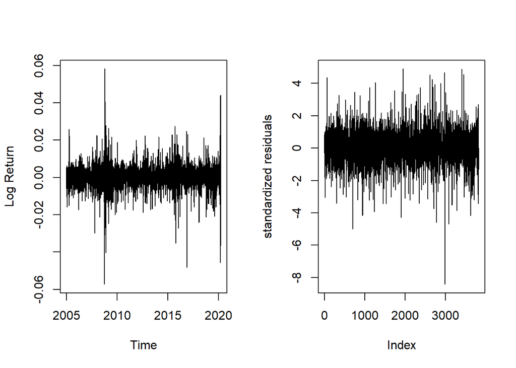

```r
par(mfrow=c(1,2))
plot(LLY$Date[-1], LLY.return, type='l', xlab='Time', ylab='Log Return')
# plot fitted residuals of the best GARCH model
plot(residuals(mpq),type='h',ylab='standardized residuals')
```

Figure: The left panel is the log return original series from 01/04/2005 to 03/20/2020. The right panel is the fitted residuals (standardized returns or pseudo- returns.)

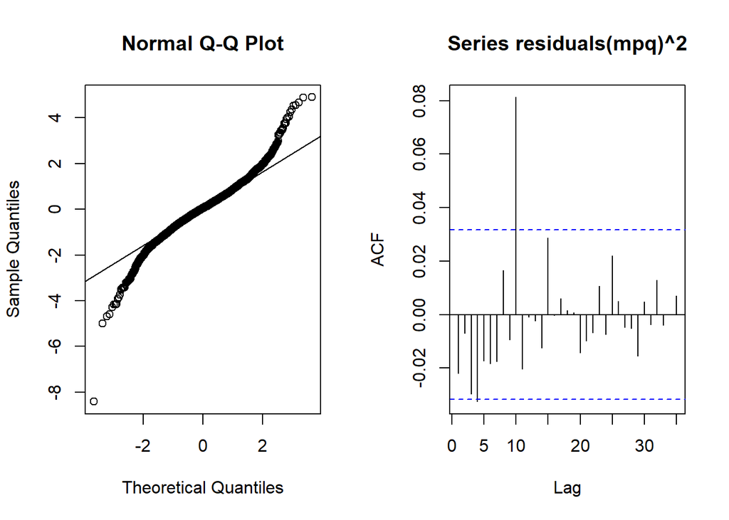

```r
par(mfrow=c(1,2))
qqnorm(residuals(mpq)); qqline(residuals(mpq))
acf(residuals(mpq)^2,na.action=na.omit)
```

Figure: The left panel is the residual QQ plot. The right panel is the squared residual ACF plot.

```r
LLY.residual=na.omit(residuals(mpq))
```

## 1.4 Dataset 1: Stock LOW

```r
LOW = mysheets$LOW
LOW.return = na.omit(LOW$`Log Return`)
```

The original log return series is plotted in Figure on the left panel. The fitted residuals (standardized returns or pseudo-returns) are plotted on the right panel.

### 1.4.1

```r
# prints ssr and best parameters
best_params <- select_best_model(LOW.return)
```

```
## [1] 3752.975
## [1] 2 2
```

```r
o = capture.output(mpq <- garch(x=LOW.return,order=best_params))
summary(mpq)
```

```
##
## Call:
## garch(x = LOW.return, order = best_params)
##
## Model:
## GARCH(2,2)
##
## Residuals:
##      Min       1Q   Median       3Q      Max
## -8.54097 -0.53378  0.01902  0.55716  6.63831
##
## Coefficient(s):
##     Estimate  Std. Error  t value Pr(>|t|)
## a0 5.449e-06          NA       NA       NA
## a1 1.123e-01          NA       NA       NA
## a2 1.304e-01          NA       NA       NA
## b1 2.257e-01          NA       NA       NA
## b2 4.718e-01          NA       NA       NA
##
## Diagnostic Tests:
##  Jarque Bera Test
##
## data:  Residuals
## X-squared = 3638.7, df = 2, p-value < 2.2e-16
##
##
##  Box-Ljung test
##
## data:  Squared.Residuals
## X-squared = 0.47682, df = 1, p-value = 0.4899
```

The best fitted model is GARCH(2,2) with the following estimated parameter values and standard errors.

Report the sum of the squared error of the final model.

```r
sum(na.omit(mpq$residuals)^2)
```

```
## [1] 3752.975
```

State the reason why this model is the final model.

GARCH(2,2) gives the smallest sum of squared residuals for this dataset.

### 1.4.2 Some diagnostic results

```r
shapiro.test(na.omit(residuals(mpq)))
```

```
##
##  Shapiro-Wilk normality test
##
## data:  na.omit(residuals(mpq))
## W = 0.95904, p-value < 2.2e-16
```

```r
jarque.bera.test(na.omit(residuals(mpq)))
```

```
##
##  Jarque Bera Test
##
## data:  na.omit(residuals(mpq))
## X-squared = 3638.7, df = 2, p-value < 2.2e-16
```

```r
cat('skewness: ', skewness(na.omit(residuals(mpq))), '\n')
```

```
## skewness:  -0.05093237
```

```r
cat('kurtosis: ', kurtosis(na.omit(residuals(mpq))))
```

```
## kurtosis:  4.775853
```

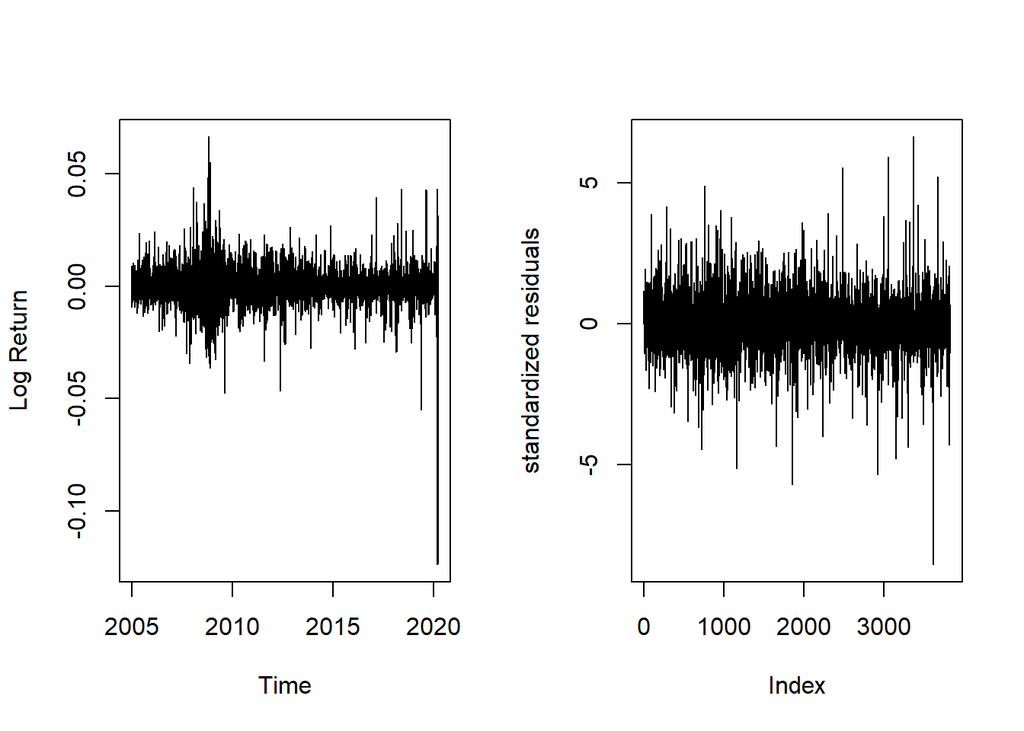

```r
par(mfrow=c(1,2))
plot(LOW$Date[-1], LOW.return, type='l', xlab='Time', ylab='Log Return')
# plot fitted residuals of the best GARCH model
plot(residuals(mpq),type='h',ylab='standardized residuals')
```

Figure: The left panel is the log return original series from 01/04/2005 to 03/20/2020. The right panel is the fitted residuals (standardized returns or pseudo- returns.)

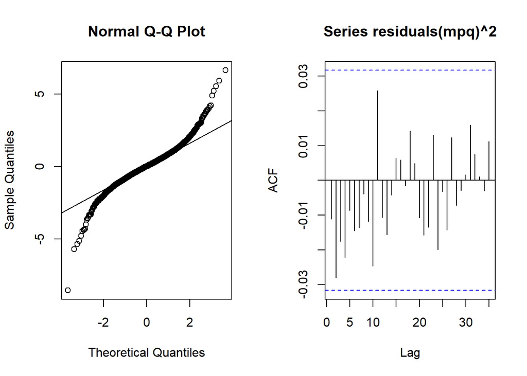

```r
par(mfrow=c(1,2))
qqnorm(residuals(mpq)); qqline(residuals(mpq))
acf(residuals(mpq)^2,na.action=na.omit)
```

Figure: The left panel is the residual QQ plot. The right panel is the squared residual ACF plot.

```r
LOW.residual=na.omit(residuals(mpq))
```

## 1.5 Dataset 1: Stock MCO

```r
MCO = mysheets$MCO
MCO.return = na.omit(MCO$`Log Return`)
```

The original log return series is plotted in Figure on the left panel. The fitted residuals (standardized returns or pseudo-returns) are plotted on the right panel.

### 1.5.1

```r
# prints ssr and best parameters
best_params <- select_best_model(MCO.return)
```

```
## [1] 3773.204
## [1] 1 2
```

```r
o = capture.output(mpq <- garch(x=MCO.return,order=best_params))
```

```r
summary(mpq)
```

```
##
## Call:
## garch(x = MCO.return, order = best_params)
##
## Model:
## GARCH(1,2)
##
## Residuals:
##       Min        1Q    Median        3Q       Max
## -10.72984  -0.46826   0.05438   0.58179   7.25452
##
## Coefficient(s):
##     Estimate  Std. Error  t value Pr(>|t|)
## a0 3.643e-06   3.221e-07    11.31   <2e-16 ***
## a1 1.645e-01   1.309e-02    12.56   <2e-16 ***
## a2 5.127e-09   1.776e-02     0.00        1
## b1 8.064e-01   1.427e-02    56.49   <2e-16 ***
## ---
## Signif. codes:  0 '***' 0.001 '**' 0.01 '*' 0.05 '.' 0.1 ' ' 1
##
## Diagnostic Tests:
##  Jarque Bera Test
##
## data:  Residuals
## X-squared = 14350, df = 2, p-value < 2.2e-16
##
##
##  Box-Ljung test
##
## data:  Squared.Residuals
## X-squared = 0.026958, df = 1, p-value = 0.8696
```

The best fitted model is GARCH(1,2) with the following estimated parameter values and standard errors.

Report the sum of the squared error of the final model.

```r
sum(na.omit(mpq$residuals)^2)
```

```
## [1] 3773.204
```

State the reason why this model is the final model.

GARCH(1,2) gives the smallest sum of squared residuals for this dataset.

### 1.5.2 Some diagnostic results

```r
shapiro.test(na.omit(residuals(mpq)))
```

```
##
##  Shapiro-Wilk normality test
##
## data:  na.omit(residuals(mpq))
## W = 0.93483, p-value < 2.2e-16
```

```r
jarque.bera.test(na.omit(residuals(mpq)))
```

```
##
##  Jarque Bera Test
##
## data:  na.omit(residuals(mpq))
## X-squared = 14350, df = 2, p-value < 2.2e-16
```

```r
cat('skewness: ', skewness(na.omit(residuals(mpq))), '\n')
```

```
## skewness:  -0.5428057
```

```r
cat('kurtosis: ', kurtosis(na.omit(residuals(mpq))))
```

```
## kurtosis:  9.424122
```

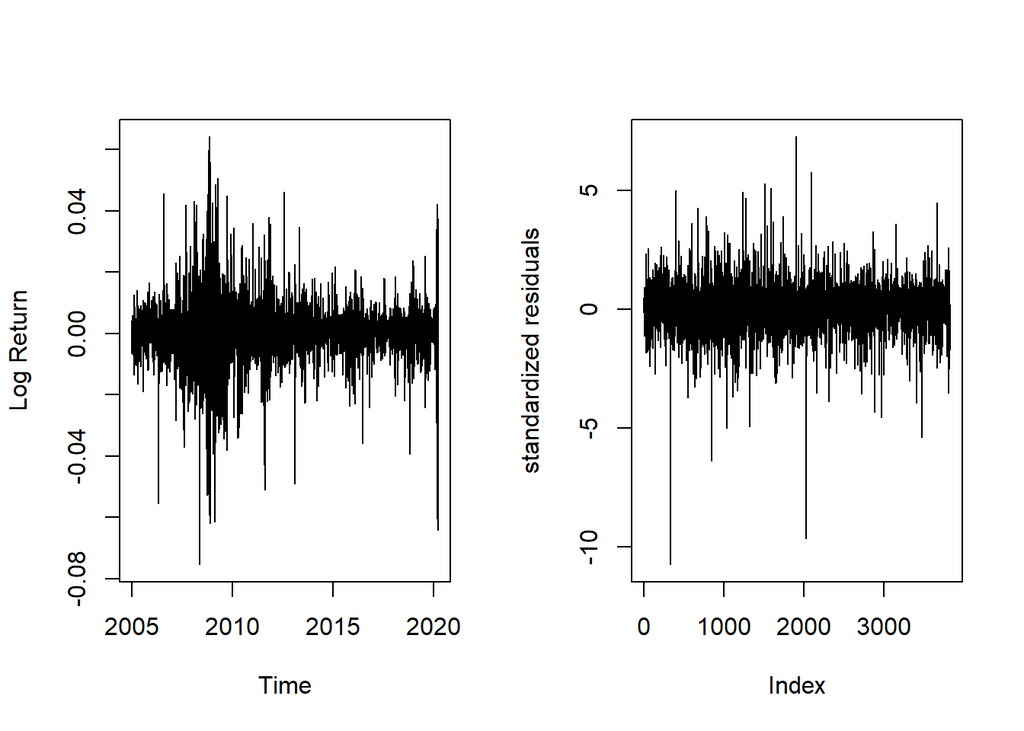

```r
par(mfrow=c(1,2))
plot(MCO$Date[-1], MCO.return, type='l', xlab='Time', ylab='Log Return')
# plot fitted residuals of the best GARCH model
plot(residuals(mpq),type='h',ylab='standardized residuals')
```

Figure: The left panel is the log return original series from 01/04/2005 to 03/20/2020. The right panel is the fitted residuals (standardized returns or pseudo- returns.)

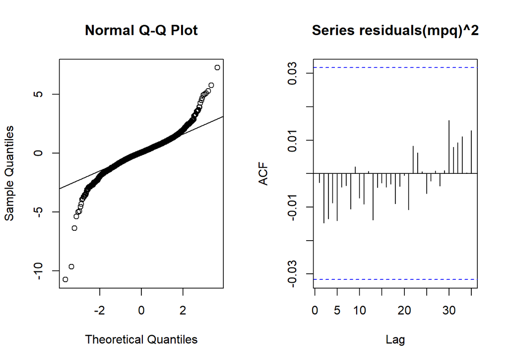

```r
par(mfrow=c(1,2))
qqnorm(residuals(mpq)); qqline(residuals(mpq))
acf(residuals(mpq)^2,na.action=na.omit)
```

Figure: The left panel is the residual QQ plot. The right panel is the squared residual ACF plot.

```r
MCO.residual=na.omit(residuals(mpq))
```

## 1.6 Dataset 1: Stock MSFT

```r
MSFT = mysheets$MSFT
MSFT.return = na.omit(MSFT$`Log Return`)
```

The original log return series is plotted in Figure on the left panel. The fitted residuals (standardized returns or pseudo-returns) are plotted on the right panel.

### 1.6.1

```r
# prints ssr and best parameters
best_params <- select_best_model(MSFT.return)
```

```
## [1] 3772.626
## [1] 1 2
```

```r
o = capture.output(mpq <- garch(x=MSFT.return,order=best_params))
```

```r
summary(mpq)
```

```
##
## Call:
## garch(x = MSFT.return, order = best_params)
##
## Model:
## GARCH(1,2)
##
## Residuals:
##       Min        1Q    Median        3Q       Max
## -11.58003  -0.48279   0.02266   0.56984   7.05862
##
## Coefficient(s):
##     Estimate  Std. Error  t value Pr(>|t|)
## a0 4.311e-06   4.075e-07    10.58   <2e-16 ***
## a1 1.791e-01   1.604e-02    11.17   <2e-16 ***
## a2 6.559e-10   1.890e-02     0.00        1
## b1 7.525e-01   2.019e-02    37.28   <2e-16 ***
## ---
## Signif. codes:  0 '***' 0.001 '**' 0.01 '*' 0.05 '.' 0.1 ' ' 1
##
## Diagnostic Tests:
##  Jarque Bera Test
##
## data:  Residuals
## X-squared = 17052, df = 2, p-value < 2.2e-16
##
##
##  Box-Ljung test
##
## data:  Squared.Residuals
## X-squared = 0.82838, df = 1, p-value = 0.3627
```

The best fitted model is GARCH(1,2) with the following estimated parameter values and standard errors.

Report the sum of the squared error of the final model.

```r
sum(na.omit(mpq$residuals)^2)
```

```
## [1] 3772.626
```

State the reason why this model is the final model.

GARCH(1,2) gives the smallest sum of squared residuals for this dataset.

### 1.6.2 Some diagnostic results

```r
shapiro.test(na.omit(residuals(mpq)))
```

```
##
##  Shapiro-Wilk normality test
##
## data:  na.omit(residuals(mpq))
## W = 0.9334, p-value < 2.2e-16
```

```r
jarque.bera.test(na.omit(residuals(mpq)))
```

```
##
##  Jarque Bera Test
##
## data:  na.omit(residuals(mpq))
## X-squared = 17052, df = 2, p-value < 2.2e-16
```

```r
cat('skewness: ', skewness(na.omit(residuals(mpq))), '\n')
```

```
## skewness:  -0.3523854
```

```r
cat('kurtosis: ', kurtosis(na.omit(residuals(mpq))))
```

```
## kurtosis:  10.31701
```

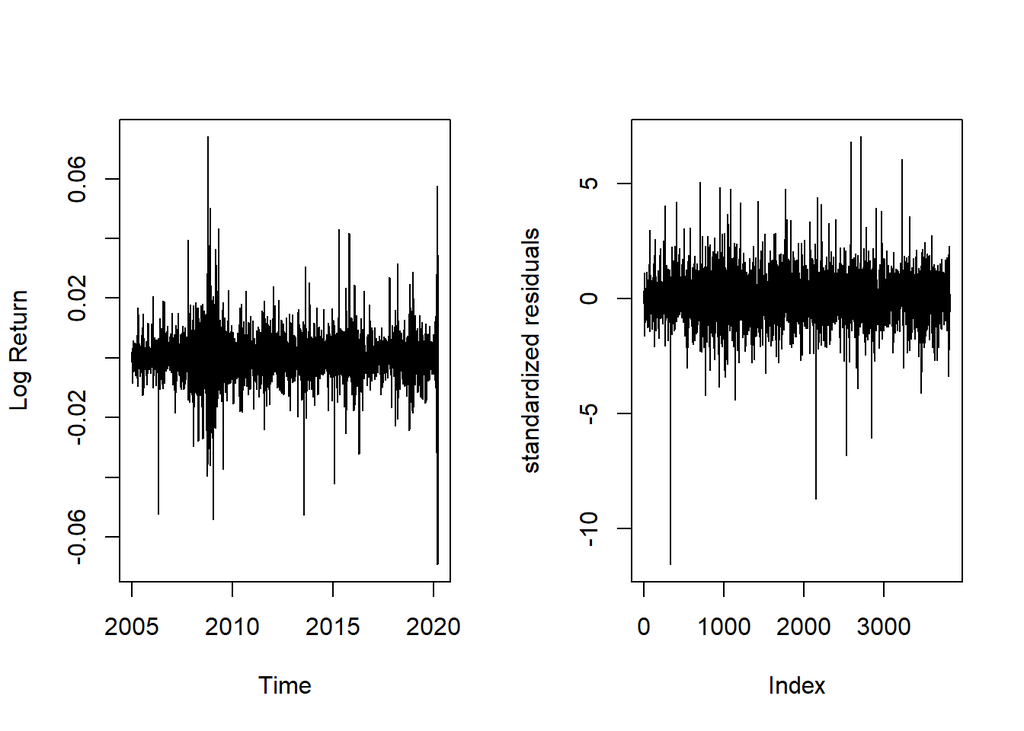

```r
par(mfrow=c(1,2))
plot(MSFT$Date[-1], MSFT.return, type='l', xlab='Time', ylab='Log Return')
# plot fitted residuals of the best GARCH model
plot(residuals(mpq),type='h',ylab='standardized residuals')
```

Figure: The left panel is the log return original series from 01/04/2005 to 03/20/2020. The right panel is the fitted residuals (standardized returns or pseudo- returns.)

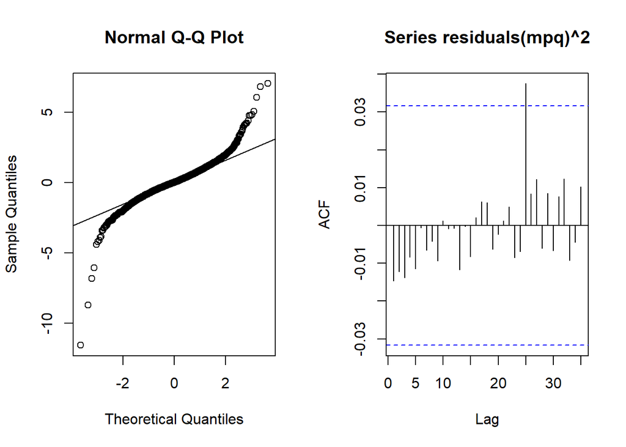

```r
par(mfrow=c(1,2))
qqnorm(residuals(mpq)); qqline(residuals(mpq))
acf(residuals(mpq)^2,na.action=na.omit)
```

Figure: The left panel is the residual QQ plot. The right panel is the squared residual ACF plot.

```r
MSFT.residual=na.omit(residuals(mpq))
```

## 1.7 Dataset 1: Stock PFE

```r
PFE = mysheets$PFE
PFE.return = na.omit(PFE$`Log Return`)
```

The original log return series is plotted in Figure on the left panel. The fitted residuals (standardized returns or pseudo-returns) are plotted on the right panel.

### 1.7.1

```r
# prints ssr and best parameters
best_params <- select_best_model(PFE.return)
```

```
## [1] 3802.875
## [1] 1 2
```

```r
o = capture.output(mpq <- garch(x=PFE.return,order=best_params))
```

```r
summary(mpq)
```

```
##
## Call:
## garch(x = PFE.return, order = best_params)
##
## Model:
## GARCH(1,2)
##
## Residuals:
##     Min      1Q  Median      3Q     Max
## -9.6496 -0.5520  0.0000  0.5713  5.5237
##
## Coefficient(s):
##     Estimate  Std. Error  t value Pr(>|t|)
## a0 1.353e-06   1.609e-07    8.411   <2e-16 ***
## a1 1.427e-01   1.509e-02    9.457   <2e-16 ***
## a2 3.126e-10   1.653e-02    0.000        1
## b1 8.309e-01   1.298e-02   64.004   <2e-16 ***
## ---
## Signif. codes:  0 '***' 0.001 '**' 0.01 '*' 0.05 '.' 0.1 ' ' 1
##
## Diagnostic Tests:
##  Jarque Bera Test
##
## data:  Residuals
## X-squared = 5047.9, df = 2, p-value < 2.2e-16
##
##
##  Box-Ljung test
##
## data:  Squared.Residuals
## X-squared = 0.021347, df = 1, p-value = 0.8838
```

The best fitted model is GARCH(1,2) with the following estimated parameter values and standard errors.

Report the sum of the squared error of the final model.

```r
sum(na.omit(mpq$residuals)^2)
```

```
## [1] 3802.875
```

State the reason why this model is the final model.

GARCH(1,2) gives the smallest sum of squared residuals for this dataset.

### 1.7.2 Some diagnostic results

```r
shapiro.test(na.omit(residuals(mpq)))
```

```
##
##  Shapiro-Wilk normality test
##
## data:  na.omit(residuals(mpq))
## W = 0.96319, p-value < 2.2e-16
```

```r
jarque.bera.test(na.omit(residuals(mpq)))
```

```
##
##  Jarque Bera Test
##
## data:  na.omit(residuals(mpq))
## X-squared = 5047.9, df = 2, p-value < 2.2e-16
```

```r
cat('skewness: ', skewness(na.omit(residuals(mpq))), '\n')
```

```
## skewness:  -0.348042
```

```r
cat('kurtosis: ', kurtosis(na.omit(residuals(mpq))))
```

```
## kurtosis:  5.583209
```

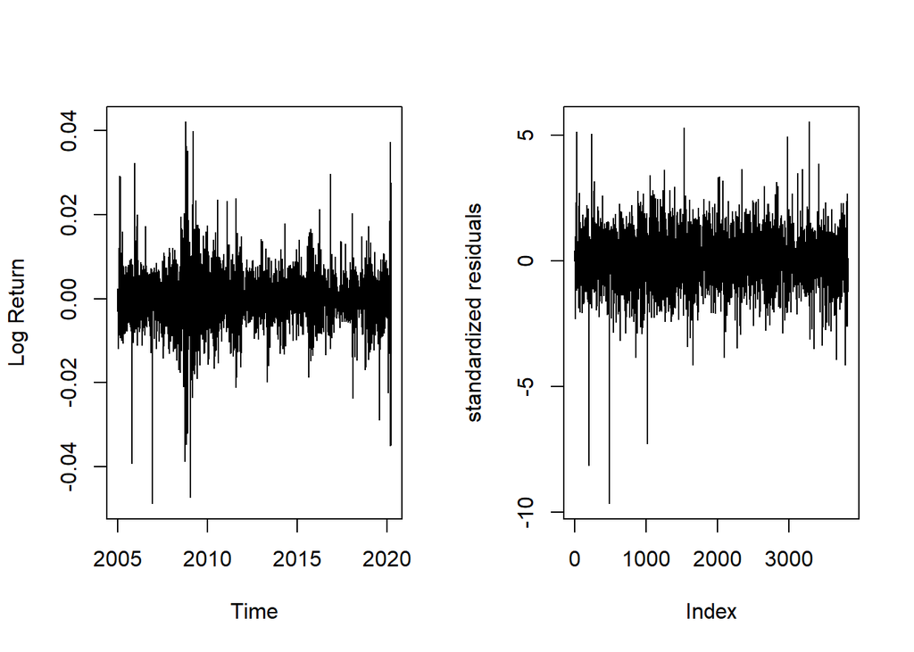

```r
par(mfrow=c(1,2))
plot(PFE$Date[-1], PFE.return, type='l', xlab='Time', ylab='Log Return')
# plot fitted residuals of the best GARCH model
plot(residuals(mpq),type='h',ylab='standardized residuals')
```

Figure: The left panel is the log return original series from 01/04/2005 to 03/20/2020. The right panel is the fitted residuals (standardized returns or pseudo- returns.)

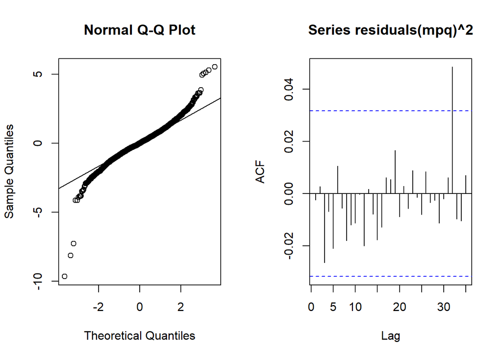

```r
par(mfrow=c(1,2))
qqnorm(residuals(mpq)); qqline(residuals(mpq))
acf(residuals(mpq)^2,na.action=na.omit)
```

Figure: The left panel is the residual QQ plot. The right panel is the squared residual ACF plot.

```r
PFE.residual=na.omit(residuals(mpq))
```

## 1.8 Dataset 1: Stock ROK

```r
ROK = mysheets$ROK
ROK.return = na.omit(ROK$`Log Return`)
```

The original log return series is plotted in Figure on the left panel. The fitted residuals (standardized returns or pseudo-returns) are plotted on the right panel.

### 1.8.1

```r
# prints ssr and best parameters
best_params <- select_best_model(ROK.return)
```

```
## [1] 3706.784
## [1] 2 1
```

```r
o = capture.output(mpq <- garch(x=ROK.return,order=best_params))
```

```r
summary(mpq)
```

```
##
## Call:
## garch(x = ROK.return, order = best_params)
##
## Model:
## GARCH(2,1)
##
## Residuals:
##      Min       1Q   Median       3Q      Max
## -7.02956 -0.51420  0.02852  0.55477  6.39944
##
## Coefficient(s):
##     Estimate  Std. Error  t value Pr(>|t|)
## a0 6.824e-06   5.191e-07   13.146  < 2e-16 ***
## a1 2.990e-01   1.760e-02   16.983  < 2e-16 ***
## b1 2.541e-01   4.079e-02    6.229 4.71e-10 ***
## b2 4.061e-01   3.696e-02   10.990  < 2e-16 ***
## ---
## Signif. codes:  0 '***' 0.001 '**' 0.01 '*' 0.05 '.' 0.1 ' ' 1
##
## Diagnostic Tests:
##  Jarque Bera Test
##
## data:  Residuals
## X-squared = 3282, df = 2, p-value < 2.2e-16
##
##
##  Box-Ljung test
##
## data:  Squared.Residuals
## X-squared = 7.5971, df = 1, p-value = 0.005846
```

The best fitted model is GARCH(2,1) with the following estimated parameter values and standard errors.

Report the sum of the squared error of the final model.

```r
sum(na.omit(mpq$residuals)^2)
```

```
## [1] 3706.784
```

### 1.8.2 Some diagnostic results

```r
shapiro.test(na.omit(residuals(mpq)))
```

```
##
##  Shapiro-Wilk normality test
##
## data:  na.omit(residuals(mpq))
## W = 0.95807, p-value < 2.2e-16
```

```r
jarque.bera.test(na.omit(residuals(mpq)))
```

```
##
##  Jarque Bera Test
##
## data:  na.omit(residuals(mpq))
## X-squared = 3282, df = 2, p-value < 2.2e-16
```

```r
cat('skewness: ', skewness(na.omit(residuals(mpq))), '\n')
```

```
## skewness:  -0.08604433
```

```r
cat('kurtosis: ', kurtosis(na.omit(residuals(mpq))))
```

```
## kurtosis:  4.533523
```

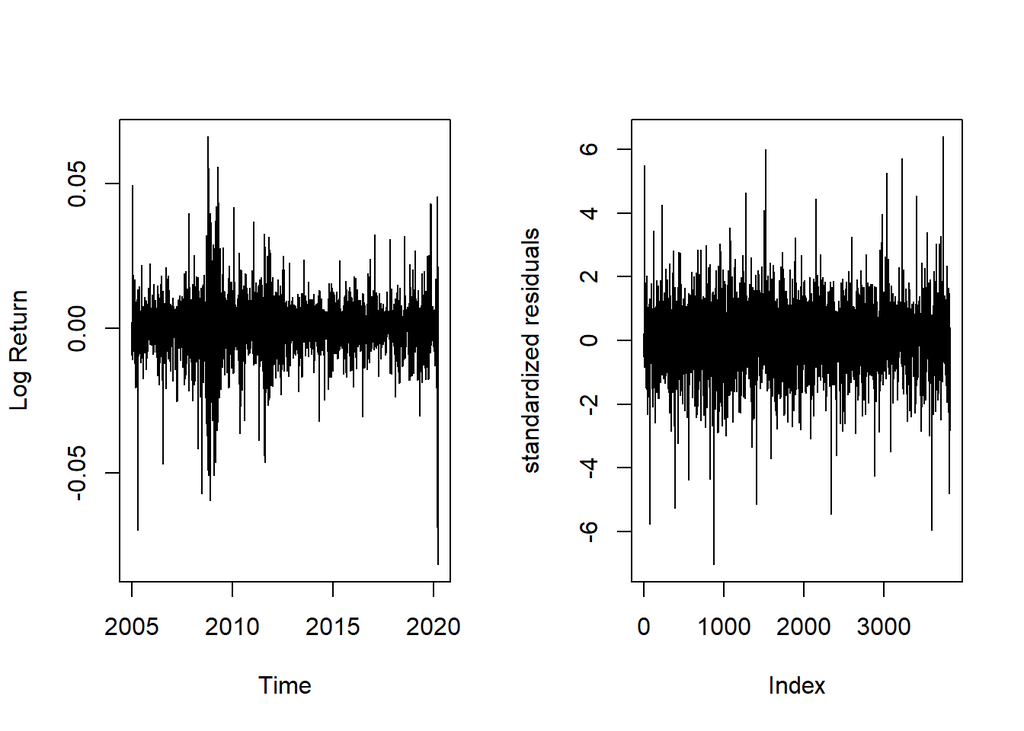

```r
par(mfrow=c(1,2))
plot(ROK$Date[-1], ROK.return, type='l', xlab='Time', ylab='Log Return')
# plot fitted residuals of the best GARCH model
plot(residuals(mpq),type='h',ylab='standardized residuals')
```

Figure: The left panel is the log return original series from 01/04/2005 to 03/20/2020. The right panel is the fitted residuals (standardized returns or pseudo- returns.)

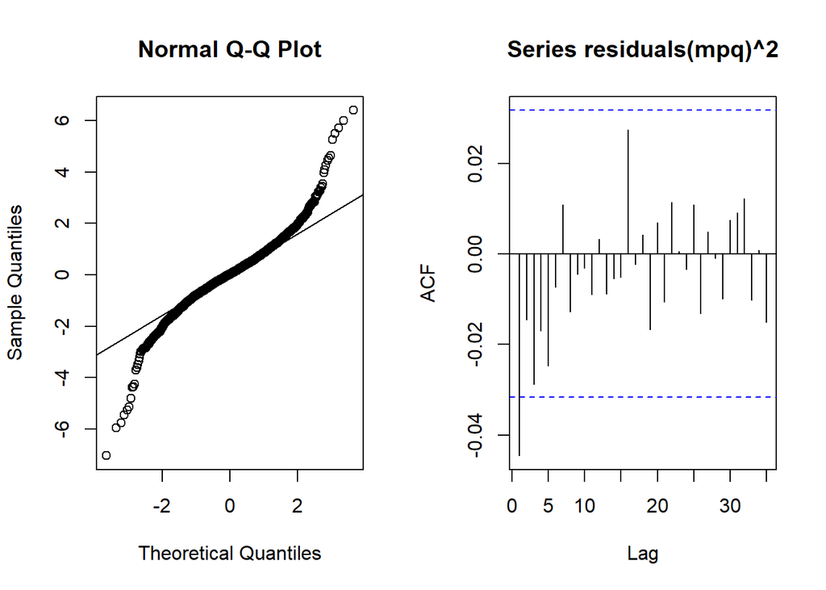

```r
par(mfrow=c(1,2))
qqnorm(residuals(mpq)); qqline(residuals(mpq))
acf(residuals(mpq)^2,na.action=na.omit)
```

Figure: The left panel is the residual QQ plot. The right panel is the squared residual ACF plot.

```r
ROK.residual=na.omit(residuals(mpq))
```

## 1.9 Dataset 1: Stock TRV

```r
TRV = mysheets$TRV
TRV.return = na.omit(TRV$`Log Return`)
```

The original log return series is plotted in Figure on the left panel. The fitted residuals (standardized returns or pseudo-returns) are plotted on the right panel.

### 1.9.1

```r
# prints ssr and best parameters
best_params <- select_best_model(TRV.return)
```

```
## [1] 3761.931
## [1] 1 2
```

```r
o = capture.output(mpq <- garch(x=TRV.return,order=best_params))
```

```r
summary(mpq)
```

```
##
## Call:
## garch(x = TRV.return, order = best_params)
##
## Model:
## GARCH(1,2)
##
## Residuals:
##      Min       1Q   Median       3Q      Max
## -7.83779 -0.51256  0.04509  0.57973  6.88621
##
## Coefficient(s):
##     Estimate  Std. Error  t value Pr(>|t|)
## a0 8.292e-07   8.897e-08    9.320  < 2e-16 ***
## a1 1.012e-01   1.427e-02    7.093 1.31e-12 ***
## a2 2.096e-09   1.602e-02    0.000        1
## b1 8.843e-01   7.008e-03  126.187  < 2e-16 ***
## ---
## Signif. codes:  0 '***' 0.001 '**' 0.01 '*' 0.05 '.' 0.1 ' ' 1
##
## Diagnostic Tests:
##  Jarque Bera Test
##
## data:  Residuals
## X-squared = 4367.7, df = 2, p-value < 2.2e-16
##
##
##  Box-Ljung test
##
## data:  Squared.Residuals
## X-squared = 0.75537, df = 1, p-value = 0.3848
```

The best fitted model is GARCH(1,2) with the following estimated parameter values and standard errors.

Report the sum of the squared error of the final model.

```r
sum(na.omit(mpq$residuals)^2)
```

```
## [1] 3761.931
```

State the reason why this model is the final model.

GARCH(1,2) gives the smallest sum of squared residuals for this dataset.

### 1.9.2 Some diagnostic results

```r
shapiro.test(na.omit(residuals(mpq)))
```

```
##
##  Shapiro-Wilk normality test
##
## data:  na.omit(residuals(mpq))
## W = 0.95639, p-value < 2.2e-16
```

```r
jarque.bera.test(na.omit(residuals(mpq)))
```

```
##
##  Jarque Bera Test
##
## data:  na.omit(residuals(mpq))
## X-squared = 4367.7, df = 2, p-value < 2.2e-16
```

```r
cat('skewness: ', skewness(na.omit(residuals(mpq))), '\n')
```

```
## skewness:  -0.4956872
```

```r
cat('kurtosis: ', kurtosis(na.omit(residuals(mpq))))
```

```
## kurtosis:  5.138883
```

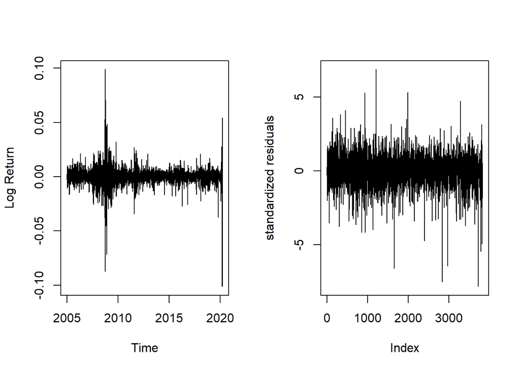

```r
par(mfrow=c(1,2))
plot(TRV$Date[-1], TRV.return, type='l', xlab='Time', ylab='Log Return')
# plot fitted residuals of the best GARCH model
plot(residuals(mpq),type='h',ylab='standardized residuals')
```

Figure: The left panel is the log return original series from 01/04/2005 to 03/20/2020. The right panel is the fitted residuals (standardized returns or pseudo- returns.)

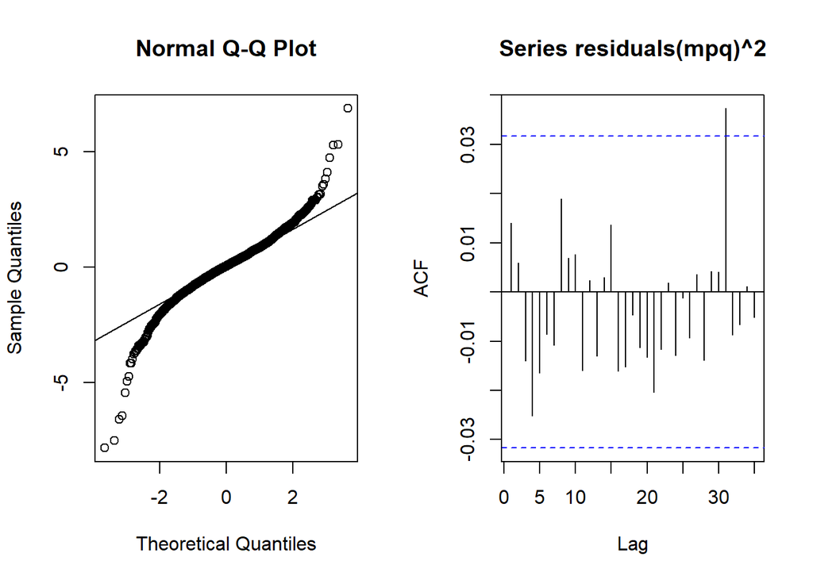

```r
par(mfrow=c(1,2))
qqnorm(residuals(mpq)); qqline(residuals(mpq))
acf(residuals(mpq)^2,na.action=na.omit)
```

Figure: The left panel is the residual QQ plot. The right panel is the squared residual ACF plot.

```r
TRV.residual=na.omit(residuals(mpq))
```

## 1.10 Dataset 1: Stock TXT

```r
TXT = mysheets$TXT
TXT.return = na.omit(TXT$`Log Return`)
```

The original log return series is plotted in Figure on the left panel. The fitted residuals (standardized returns or pseudo-returns) are plotted on the right panel.

### 1.10.1

```r
# prints ssr and best parameters
best_params <- select_best_model(TXT.return)
```

```
## [1] 3816.051
## [1] 1 2
```

```r
o = capture.output(mpq <- garch(x=TXT.return,order=best_params))
```

```r
summary(mpq)
```

```
##
## Call:
## garch(x = TXT.return, order = best_params)
##
## Model:
## GARCH(1,2)
##
## Residuals:
##      Min       1Q   Median       3Q      Max
## -7.71315 -0.52860  0.01008  0.57339  8.79217
##
## Coefficient(s):
##     Estimate  Std. Error  t value Pr(>|t|)
## a0 1.841e-06   1.174e-07   15.686  < 2e-16 ***
## a1 6.465e-02   1.286e-02    5.029 4.92e-07 ***
## a2 4.805e-02   1.540e-02    3.121   0.0018 **
## b1 8.788e-01   5.815e-03  151.124  < 2e-16 ***
## ---
## Signif. codes:  0 '***' 0.001 '**' 0.01 '*' 0.05 '.' 0.1 ' ' 1
##
## Diagnostic Tests:
##  Jarque Bera Test
##
## data:  Residuals
## X-squared = 9601.6, df = 2, p-value < 2.2e-16
##
##
##  Box-Ljung test
##
## data:  Squared.Residuals
## X-squared = 0.14179, df = 1, p-value = 0.7065
```

The best fitted model is GARCH(1,2) with the following estimated parameter values and standard errors.

Report the sum of the squared error of the final model.

```r
sum(na.omit(mpq$residuals)^2)
```

```
## [1] 3816.051
```

State the reason why this model is the final model.

GARCH(1,2) gives the smallest sum of squared residuals for this dataset.

### 1.10.2 Some diagnostic results

```r
shapiro.test(na.omit(residuals(mpq)))
```

```
##
##  Shapiro-Wilk normality test
##
## data:  na.omit(residuals(mpq))
## W = 0.93782, p-value < 2.2e-16
```

```r
jarque.bera.test(na.omit(residuals(mpq)))
```

```
##
##  Jarque Bera Test
##
## data:  na.omit(residuals(mpq))
## X-squared = 9601.6, df = 2, p-value < 2.2e-16
```

```r
cat('skewness: ', skewness(na.omit(residuals(mpq))), '\n')
```

```
## skewness:  0.08111025
```

```r
cat('kurtosis: ', kurtosis(na.omit(residuals(mpq))))
```

```
## kurtosis:  7.758057
```

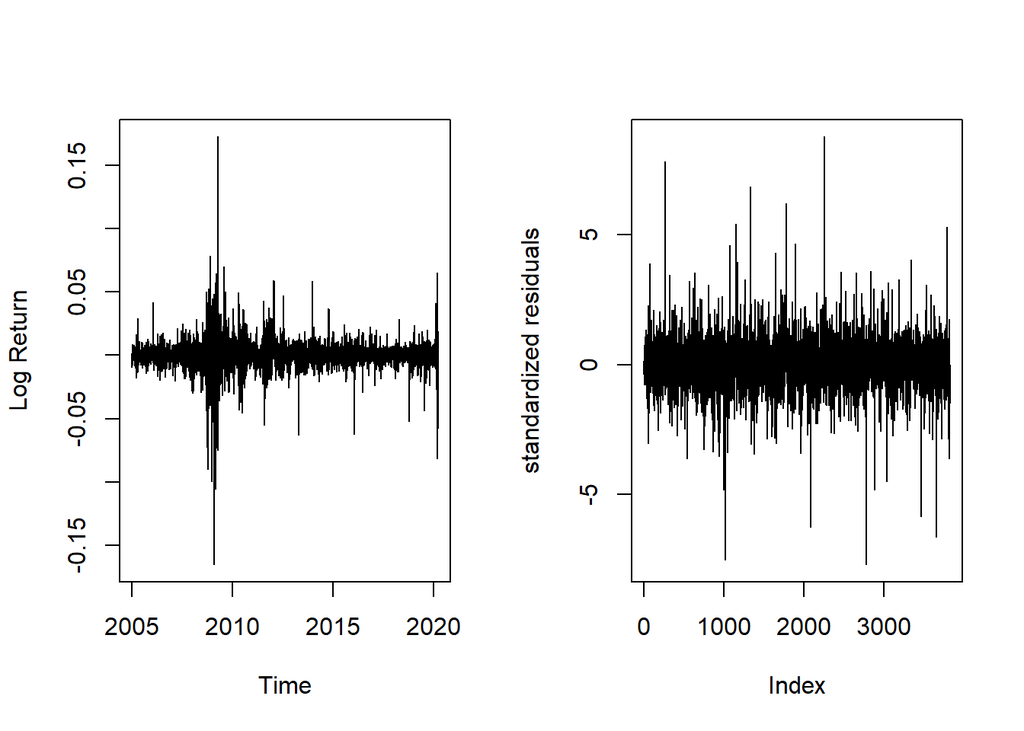

```r
par(mfrow=c(1,2))
plot(TXT$Date[-1], TXT.return, type='l', xlab='Time', ylab='Log Return')
# plot fitted residuals of the best GARCH model
plot(residuals(mpq),type='h',ylab='standardized residuals')
```

Figure: The left panel is the log return original series from 01/04/2005 to 03/20/2020. The right panel is the fitted residuals (standardized returns or pseudo- returns.)

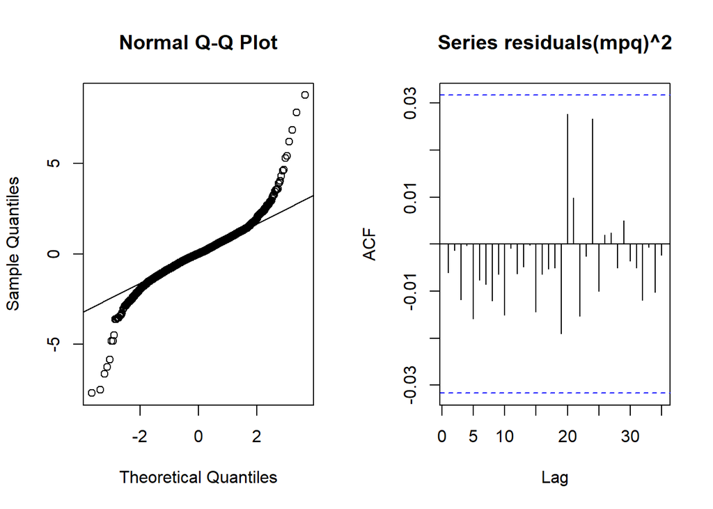

```r
par(mfrow=c(1,2))
qqnorm(residuals(mpq)); qqline(residuals(mpq))
acf(residuals(mpq)^2,na.action=na.omit)
```

Figure: The left panel is the residual QQ plot. The right panel is the squared residual ACF plot.

```r
TXT.residual=na.omit(residuals(mpq))
```

```r
# Gather model redisuals into a data frame
mpq_residuals = data.frame(BLL.residual, F.residual, LLY.residual, LOW.residual, MCO.residual, MSFT.residual, PFE.residual, ROK.residual, TRV.residual, TXT.residual)
# Get log return dataframe and closing price dataframe for all 10 companies
all_logret = mysheets$LOGRET
all_price = mysheets$PRICE
```

# 2 Step 5

```r
c_1 = rep(1/10, 10)
c_best = rep(0, 10)
```

1. Report the sample mean and sample standard deviation ($c_i=1/10$) of $r_t$.

```r
# Compute r_t for c_i=1/10
rt.c1 = as.numeric(data.matrix(all_logret) %*% matrix(c_1, nrow=10, ncol=1))
```

```r
cat('mean: ',mean(rt.c1), '\n')
```

```
## mean:  7.376142e-05
```

```r
cat('standard deviation: ', sd(rt.c1))
```

```
## standard deviation:  0.006107586
```

```r
# Alternative way to compute mean of r_t
# sum(colSums(all_logret) * c_1)/3829
```

2. Report the sample mean and sample standard deviation ($c_i=?$) of $r_t$.

```r
library(Surrogate)
best_mean = mean(rt.c1)
best_sd = sd(rt.c1)
c_best = c_1
set.seed(30)
for (i in 1:50000){
  c_curr = as.numeric(RandVec(a=0, b=1, s=1, n=10, m=1, Seed=sample(1:2147483647, size = 1))$`RandVecOutput`)

  rt.curr = as.numeric(data.matrix(all_logret) %*% matrix(c_curr, nrow=10, ncol=1))
  curr_mean = mean(rt.curr)
  curr_sd = sd(rt.curr)
  if (curr_mean > best_mean && curr_sd <= best_sd) {
    best_mean = curr_mean
    best_sd = curr_sd
    c_best = c_curr
  }
}

cat('c_best: ', c_best, '\n')
```

```
## c_best:  0.4226344 0.0207333 0.1406372 0.06416519 0.007635655 0.1853899 0.0007749104 0.0756523 0.08161502 0.0007620961
```

```r
cat('mean: ',best_mean, '\n')
```

```
## mean:  0.0001452132
```

```r
cat('standard deviation: ', best_sd)
```

```
## standard deviation:  0.005593865
```

```r
# Compute r_t for c_best
# rt.cbest = as.numeric(data.matrix(all_logret) %*% matrix(c_best, nrow=10, ncol=1))
```

3. Report your optimization procedure.

I used Monte Carlo method to simulate the best c vector. I generated a lot of c vectors $c(c_1,c_2,...,c_{10})$ that are uniformly distributed in the space where $c_1+c_2+...+c_{10}=1$ and $c_i\geq0$. I select the best c vector which generates the largest objective value and satisfy the condition that the std smaller than or equal to the std from c(1/10).

# 3 Step 6

1. Report the sample mean and sample standard deviation ($c_i=1/10$) of $r_t^\epsilon$.

```r
# Compute r_t^epsilon for c_i=1/10
rtep.c1 = as.numeric(data.matrix(mpq_residuals) %*% matrix(c_1, nrow=10, ncol=1))
```

```r
cat('mean: ',mean(rtep.c1), '\n')
```

```
## mean:  0.01828762
```

```r
cat('standard deviation: ', sd(rtep.c1))
```

```
## standard deviation:  0.6505152
```

2. Report the sample mean and sample standard deviation ($c_i=?$) of $r_t^\epsilon$.

```r
best_mean = mean(rtep.c1)
best_sd = sd(rtep.c1)
c_best = c_1
set.seed(10)
for (i in 1:50000){
  c_curr = as.numeric(RandVec(a=0, b=1, s=1, n=10, m=1, Seed=sample(1:2147483647, size = 1))$`RandVecOutput`)

  rtep.curr = as.numeric(data.matrix(mpq_residuals) %*% matrix(c_curr, nrow=10, ncol=1))
  curr_mean = mean(rtep.curr)
  curr_sd = sd(rtep.curr)
  if (curr_mean > best_mean && curr_sd <= best_sd) {
    best_mean = curr_mean
    best_sd = curr_sd
    c_best = c_curr
  }
}

cat('c_best: ', c_best, '\n')
```

```
## c_best:  0.03089828 0.1176029 0.1693533 0.1289134 0.1167062 0.13979 0.09868266 0.07171978 0.07194399 0.05438955
```

```r
cat('mean: ',best_mean, '\n')
```

```
## mean:  0.01835864
```

```r
cat('standard deviation: ', best_sd)
```

```
## standard deviation:  0.6493505
```

```r
# Compute r_t for c_best
# rt.cbest = as.numeric(data.matrix(mpq_residuals) %*% matrix(c_best, nrow=10, ncol=1))
```

3. Report your optimization procedure.

I used Monte Carlo method to simulate the best c vector. I generated a lot of c vectors $c(c_1,c_2,...,c_{10})$ that are uniformly distributed in the space where $c_1+c_2+...+c_{10}=1$ and $c_i\geq0$. I select the best c vector which generates the largest objective value and satisfy the condition that the std smaller than or equal to the std from c(1/10).

# 4 Step 7

```r
# this is to compute r_t^p based on c_1
# V is an intermediate vector for computation
V = as.numeric(data.matrix(all_price) %*% matrix(c_1, nrow=10, ncol=1))
rtp.c1 = log10(V[-1]) - log10(V[-length(V)])
```

1. Report the sample mean and sample standard deviation ($c_i=1/10$) of $r_t^p$.

```r
cat('mean: ',mean(rtp.c1), '\n')
```

```
## mean:  0.0001049287
```

```r
cat('standard deviation: ', sd(rtp.c1))
```

```
## standard deviation:  0.006093258
```

2. Report the sample mean and sample standard deviation ($c_i=?$) of $r_t^p$.

```r
best_mean = mean(rtp.c1)
best_sd = sd(rtp.c1)
c_best = c_1
set.seed(20)
for (i in 1:50000){
  c_curr = as.numeric(RandVec(a=0, b=1, s=1, n=10, m=1, Seed=sample(1:2147483647, size = 1))$`RandVecOutput`)

  V = as.numeric(data.matrix(all_price) %*% matrix(c_curr, nrow=10, ncol=1))
  rtp.curr = log10(V[-1]) - log10(V[-length(V)])
  curr_mean = mean(rtp.curr)
  curr_sd = sd(rtp.curr)
  if (curr_mean > best_mean && curr_sd <= best_sd) {
    best_mean = curr_mean
    best_sd = curr_sd
    c_best = c_curr
  }
}

cat('c_best: ', c_best, '\n')
```

```
## c_best:  0.5358484 0.02768855 0.110723 0.1013489 0.007871983 0.1850356 0.01902716 0.003747687 0.001922331 0.006786375
```

```r
cat('mean: ',best_mean, '\n')
```

```
## mean:  0.0001452168
```

```r
cat('standard deviation: ', best_sd)
```

```
## standard deviation:  0.005444439
```

```r
# this is to compute r_t^p based on c_1
# V is an intermediate vector for computation
V = as.numeric(data.matrix(all_price) %*% matrix(c_best, nrow=10, ncol=1))
rtp.cbest = log10(V[-1]) - log10(V[-length(V)])
```

3. Report your optimization procedure.

I used Monte Carlo method to simulate the best c vector. I generated a lot of c vectors $c(c_1,c_2,...,c_{10})$ that are uniformly distributed in the space where $c_1+c_2+...+c_{10}=1$ and $c_i\geq0$. I select the best c vector which generates the largest objective value and satisfy the condition that the std smaller than or equal to the std from c(1/10).

# 5 Step 8

## 5.1 Dataset:

$r_t^p$ from $c_i=1/10$

```r
# prints ssr and best parameters
best_params <- select_best_model(rtp.c1)
```

```
## [1] 3816.207
## [1] 2 1
```

### 5.1.1

```r
o = capture.output(mpq <- garch(x=rtp.c1,order=best_params))
summary(mpq)
```

```
##
## Call:
## garch(x = rtp.c1, order = best_params)
##
## Model:
## GARCH(2,1)
##
## Residuals:
##      Min       1Q   Median       3Q      Max
## -5.61251 -0.52827  0.07624  0.64961  4.87576
##
## Coefficient(s):
##     Estimate  Std. Error  t value Pr(>|t|)
## a0 5.692e-07          NA       NA       NA
## a1 1.165e-01          NA       NA       NA
## b1 8.651e-01          NA       NA       NA
## b2 4.384e-09          NA       NA       NA
##
## Diagnostic Tests:
##  Jarque Bera Test
##
## data:  Residuals
## X-squared = 394.43, df = 2, p-value < 2.2e-16
##
##
##  Box-Ljung test
##
## data:  Squared.Residuals
## X-squared = 0.068531, df = 1, p-value = 0.7935
```

Report the sum of the squared error of the final model.

```r
sum(na.omit(mpq$residuals)^2)
```

```
## [1] 3816.207
```

### 5.1.2 Some diagnostic results

```r
shapiro.test(na.omit(residuals(mpq)))
```

```
##
##  Shapiro-Wilk normality test
##
## data:  na.omit(residuals(mpq))
## W = 0.98631, p-value < 2.2e-16
```

```r
jarque.bera.test(na.omit(residuals(mpq)))
```

```
##
##  Jarque Bera Test
##
## data:  na.omit(residuals(mpq))
## X-squared = 394.43, df = 2, p-value < 2.2e-16
```

```r
cat('skewness: ', skewness(na.omit(residuals(mpq))), '\n')
```

```
## skewness:  -0.3635358
```

```r
cat('kurtosis: ', kurtosis(na.omit(residuals(mpq))))
```

```
## kurtosis:  1.394617
```

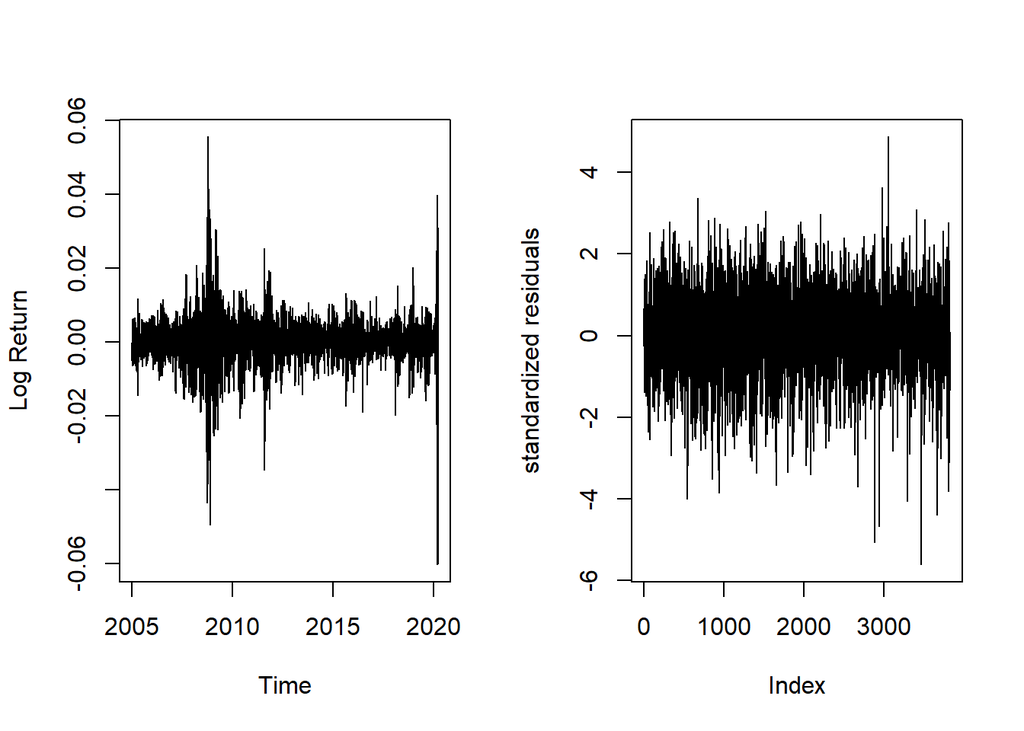

```r
par(mfrow=c(1,2))
plot(TXT$Date[-2], rtp.c1, type='l', xlab='Time', ylab='Log Return')
# plot fitted residuals of the best GARCH model
plot(residuals(mpq),type='h',ylab='standardized residuals')
```

Figure 5.1: The left panel is the log return original series from 01/05/2005 to 03/20/2020. The right panel is the fitted residuals (standardized returns or pseudo- returns.)

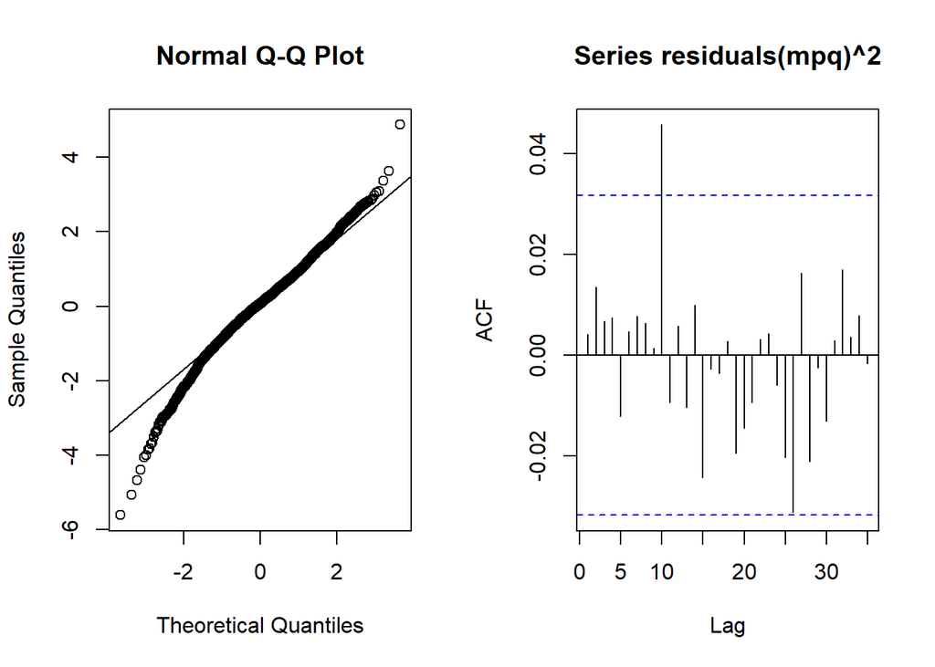

```r
par(mfrow=c(1,2))
qqnorm(residuals(mpq)); qqline(residuals(mpq))
acf(residuals(mpq)^2,na.action=na.omit)
```

Figure 5.2: The left panel is the residual QQ plot. The right panel is the squared residual ACF plot.

1. Report the sample mean and sample standard deviation ($c_i=1/10$) of $\epsilon_t$.

```r
cat('mean: ', mean(na.omit(mpq$residuals)), "\n")
```

```
## mean:  0.03621546
```

```r
cat('standard deviation: ', sd(na.omit(mpq$residuals)), "\n")
```

```
## standard deviation:  0.9980624
```

# 6 Step 9

## 6.1 Dataset:

$r_t^p$ from $c_i=?$

```r
# prints ssr and best parameters
best_params <- select_best_model(rtp.cbest)
```

```
## [1] 3744.663
## [1] 2 2
```

```r
o = capture.output(mpq <- garch(x=rtp.cbest,order=best_params))
summary(mpq)
```

```
##
## Call:
## garch(x = rtp.cbest, order = best_params)
##
## Model:
## GARCH(2,2)
##
## Residuals:
##      Min       1Q   Median       3Q      Max
## -6.22818 -0.52659  0.06439  0.64123  6.44664
##
## Coefficient(s):
##     Estimate  Std. Error  t value Pr(>|t|)
## a0 1.767e-06          NA       NA       NA
## a1 9.870e-02          NA       NA       NA
## a2 1.430e-01          NA       NA       NA
## b1 3.215e-01          NA       NA       NA
## b2 3.757e-01          NA       NA       NA
##
## Diagnostic Tests:
##  Jarque Bera Test
##
## data:  Residuals
## X-squared = 509.35, df = 2, p-value < 2.2e-16
##
##
##  Box-Ljung test
##
## data:  Squared.Residuals
## X-squared = 0.07266, df = 1, p-value = 0.7875
```

### 6.1.1

Report the sum of the squared error of the final model.

```r
sum(na.omit(mpq$residuals)^2)
```

```
## [1] 3744.663
```

### 6.1.2 Some diagnostic results

```r
shapiro.test(na.omit(residuals(mpq)))
```

```
##
##  Shapiro-Wilk normality test
##
## data:  na.omit(residuals(mpq))
## W = 0.98683, p-value < 2.2e-16
```

```r
jarque.bera.test(na.omit(residuals(mpq)))
```

```
##
##  Jarque Bera Test
##
## data:  na.omit(residuals(mpq))
## X-squared = 509.35, df = 2, p-value < 2.2e-16
```

```r
skewness(na.omit(residuals(mpq)))
```

```
## [1] -0.2150195
```

```r
kurtosis(na.omit(residuals(mpq)))
```

```
## [1] 1.73473
```

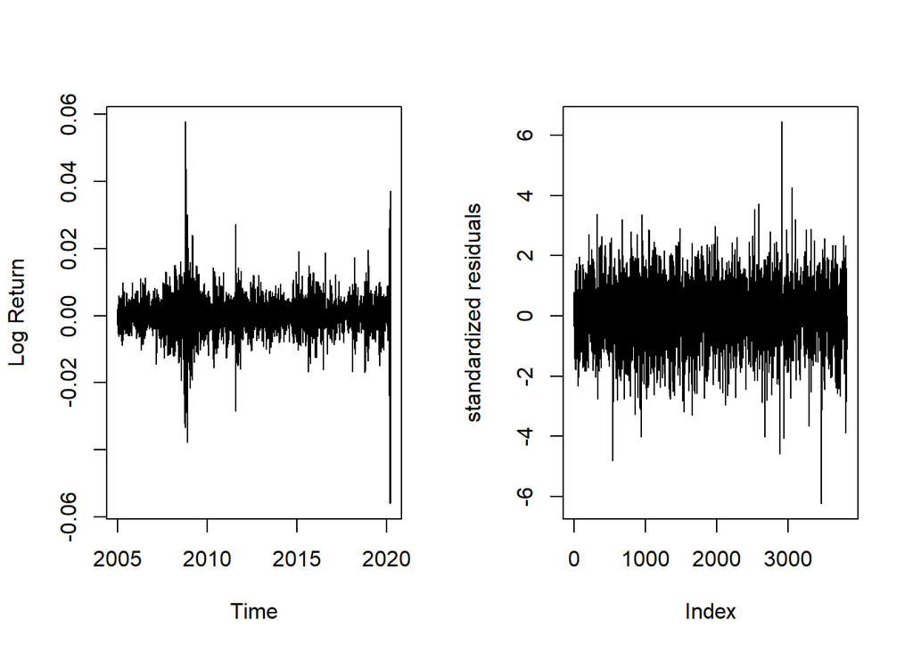

```r
par(mfrow=c(1,2))
plot(TXT$Date[-2], rtp.cbest, type='l', xlab='Time', ylab='Log Return')
# plot fitted residuals of the best GARCH model
plot(residuals(mpq),type='h',ylab='standardized residuals')
```

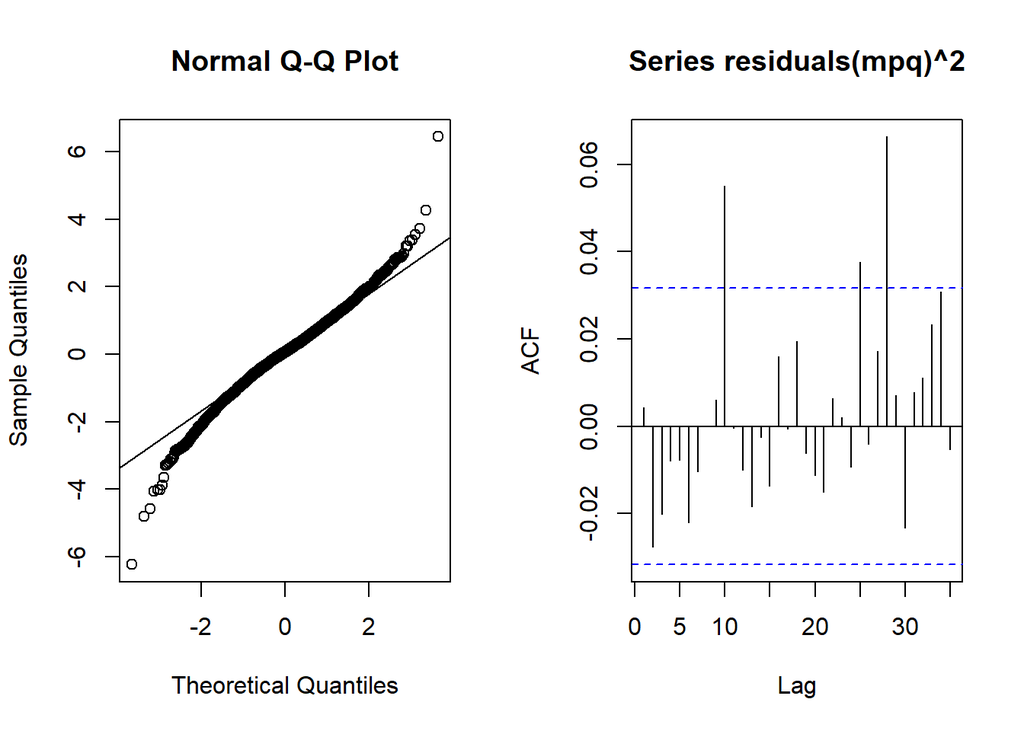

```r
par(mfrow=c(1,2))
qqnorm(residuals(mpq)); qqline(residuals(mpq))
acf(residuals(mpq)^2,na.action=na.omit)
```

Figure 6.2: The left panel is the residual QQ plot. The right panel is the squared residual ACF plot.

1. Report the sample mean and sample standard deviation ($c_i=?$) of $\epsilon_t$.

```r
cat('mean: ', mean(na.omit(mpq$residuals)), "\n")
```

```
## mean:  0.04006906
```

```r
cat('standard deviation: ', sd(na.omit(mpq$residuals)), "\n")
```

```
## standard deviation:  0.9885014
```

# 7 Step 10

Compare results from Step 5 to Step 9. (Compare the results of the best $c_i$ and mean values.)